# Caravan Insurance Challenge

Yash

June 24, 2018

# Predicting Caravan Insurance Purchases

## The data is provided by the Caravan Insurance company of its customer base. Some of the customers have already bought policies for fire risk , auto , boat etc from Caravan. Using this information we need predict whether they will purchase Caravan Home Insurance

### Load the training data and inspect the data

```r
Cins <-  read.csv.sql("C1.csv","select * from file where ORIGIN = 'train' ", header=TRUE, sep=",")

### Exclude the  first column
Caravan_train <- Cins[-1]


### Check the dimensions
dim(Caravan_train )
```

```
## [1] 5822   86
```

```r
#names(Caravan_train )


# Inspect the data
str(Caravan_train )
```

```
## 'data.frame':    5822 obs. of  86 variables:
##  $ Customer_Subtype                             : int  33 37 37 9 40 23 39 33 33 11 ...
##  $ Number_of_houses                             : int  1 1 1 1 1 1 2 1 1 2 ...
##  $ Avg_size_household                           : int  3 2 2 3 4 2 3 2 2 3 ...
##  $ Avg_age                                      : int  2 2 2 3 2 1 2 3 4 3 ...
##  $ Customer_main_type                           : int  8 8 8 3 10 5 9 8 8 3 ...
##  $ Roman_catholic                               : int  0 1 0 2 1 0 2 0 0 3 ...
##  $ Protestant                                   : int  5 4 4 3 4 5 2 7 1 5 ...
##  $ Other_religion                               : int  1 1 2 2 1 0 0 0 3 0 ...
##  $ No_religion                                  : int  3 4 4 4 4 5 5 2 6 2 ...
##  $ Married                                      : int  7 6 3 5 7 0 7 7 6 7 ...
##  $ Living_together                              : int  0 2 2 2 1 6 2 2 0 0 ...
##  $ Other_relation                               : int  2 2 4 2 2 3 0 0 3 2 ...
##  $ Singles                                      : int  1 0 4 2 2 3 0 0 3 2 ...
##  $ Household_without_children                   : int  2 4 4 3 4 5 3 5 3 2 ...
```

[output cut: 72 more lines]

```r
#head(Caravan_train )
```

### check for missing values

```r
Missing_Count <-  sum(is.na.data.frame(Caravan_train))
print(paste ("Missing count -> " , Missing_Count))
```

```
## [1] "Missing count ->  0"
```

### Its an highly unbalanced dataset. This is evident from the below bar chart

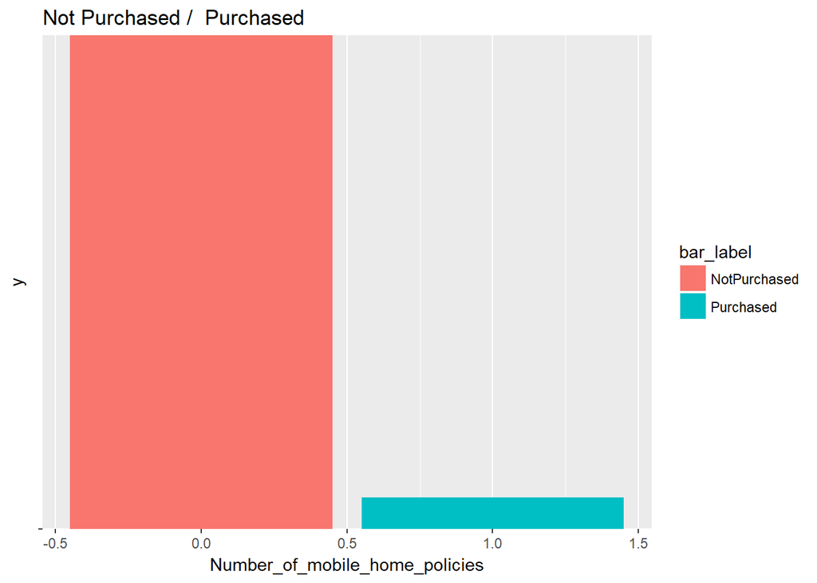

```r
bar_label <- factor(Caravan_train$Number_of_mobile_home_policies  , labels=c("NotPurchased","Purchased"))
#bar_label
ggplot(data =  Caravan_train, aes(y = "", x =Number_of_mobile_home_policies , fill = bar_label ) )+
  geom_bar(stat = "identity" ) +
  ggtitle("Not Purchased /  Purchased")
```

```r
print(paste("Insurance count : 0 -> not having insurance , 1 - Having Insurance"))
```

```
## [1] "Insurance count : 0 -> not having insurance , 1 - Having Insurance"
```

```r
table(Caravan_train$Number_of_mobile_home_policies)
```

```
##
##    0    1
## 5474  348
```

## Data Exploratory

### Education levels of population who have bought insurance. People with low education level are more likey to buy

```r
temp1 <-  ""
templ1 <-  ""
temp2 <- ""
grp_data <-  ""
grp_data <- sqldf(" select High_level_education  , Medium_level_education , Lower_level_education   from Caravan_train where Number_of_mobile_home_policies  = 1  ")
class(grp_data)
```

```
## [1] "data.frame"
```

```r
dim(grp_data)
```

```
## [1] 348   3
```

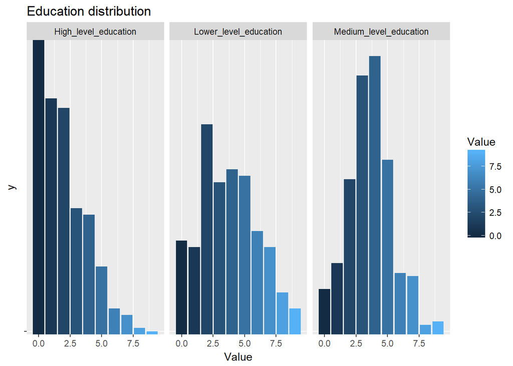

```r
temp2 <- gather(grp_data,Education,Value,1:3)

ggplot(data= temp2, aes (x = Value,y = "",fill = Value)) +
  geom_bar(stat = 'identity') +
  facet_grid(. ~ Education ) +
  ggtitle("Education distribution")
```

### Distribution of insurance buyers by Car ownership. People with 1 car are more likely to buy

```r
temp1 <-  ""
templ1 <-  ""
temp2 <- ""
grp_data <-  ""
grp_data <- sqldf(" select X1_car , X2_cars , No_car from Caravan_train where Number_of_mobile_home_policies  = 1  ")
class(grp_data)
```

```
## [1] "data.frame"
```

```r
dim(grp_data)
```

```
## [1] 348   3
```

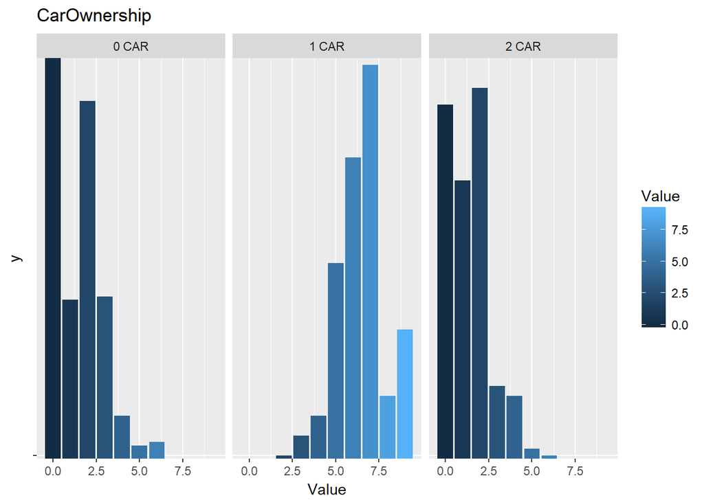

```r
names(grp_data) <- c("1 CAR","2 CAR","0 CAR")


temp2 <- gather(grp_data,CarOwnership,Value,1:3)

ggplot(data= temp2, aes (x = Value,y = "",fill = Value)) +
  geom_bar(stat = 'identity') +
  facet_grid(. ~ CarOwnership  ) +
  ggtitle("CarOwnership")
```

### Insurance policy count. We can see corelation between people having car policies3 party policy and fire risk policies.

```r
  temp1 <-  ""
templ1 <-  ""
temp2 <- ""
grp_data <-  ""
grp_data <- sqldf(" select
                   private_third_party_insurance
, third_party_insurance_firms
, third_party_insurane_agriculture
, car_policies
, delivery_van_policies
, Contribution_motorcycle_scooter
, lorry_policies
, trailer_policies
, tractor_policies
, agricultural_machines_policies
, moped_policies
, life_insurances
, private_accident_insurance_policies
, family_accidents_insurance_policies
, disability_insurance_policies
, fire_policies
, surfboard_policies
, boat_policies
, bicycle_policies
, property_insurance_policies
, social_security_insurance_policies

 from Caravan_train where Number_of_mobile_home_policies  = 1  ")
class(grp_data)
```

```
## [1] "data.frame"
```

```r
dim(grp_data)
```

```
## [1] 348  21
```

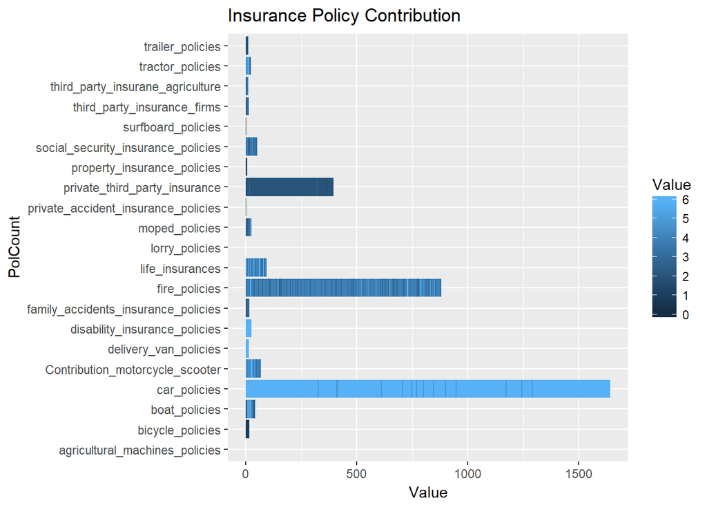

```r
temp2 <- gather(grp_data,PolCount,Value,1:21)

ggplot(data= temp2, aes (x = PolCount,y = Value,fill = Value)) +
  geom_bar(stat = 'identity' )  +
  ggtitle("Insurance Policy Contribution") +
  coord_flip()
```

### From the GBM variance influence chart, we will select only 56 variables that have impact The GBM variance influence chart was generated separately and will be included at a later state

```r
Caravan_train_SUB56  <-  subset(Caravan_train, select = c(   car_policies
                                                      ,Lower_level_education
                                                      ,fire_policies
  ,Average_income
  ,private_third_party_insurance
  ,X1_car
  ,Social_class_C
  ,Other_religion
  ,boat_policies
  ,No_car
  ,Customer_Subtype
  ,Middle_management
  ,Income_75.122.000
  ,tractor_policies
  ,Social_class_B1
  ,Social_class_D
  ,High_level_education
  ,Protestant
  ,Medium_level_education
  ,bicycle_policies
  ,Income_45.75.000
  ,Unskilled_labourers
  ,Farmer
  ,Purchasing_power
  ,Number_of_car_policies
  ,Income_._30
  ,Customer_main_type
  ,Household_with_children
  ,Income_30.45.000
  ,Rented_house
  ,moped_policies
  ,Married
  ,Social_class_B2
  ,X2_cars
  ,Skilled_labourers
  ,Social_class_A
  ,Household_without_children
  ,High_status
  ,No_religion
  ,Entrepreneur
  ,social_security_insurance_policies
  ,Home_owners
  ,third_party_insurane_agriculture
  ,Living_together
  ,Avg_size_household
  ,Avg_age
  ,Number_of_houses
  ,Singles
  ,Roman_catholic
  ,Other_relation
  ,Income_.123.000
  ,life_insurances
  ,National_Health_Service
  ,Contribution_motorcycle_scooter
  ,Private_health_insurance
  ,Number_of_life_insurances  , Number_of_mobile_home_policies   )  )

dim(Caravan_train_SUB56)
```

```
## [1] 5822   57
```

```r
head(Caravan_train_SUB56)
```

```
##   car_policies Lower_level_education fire_policies Average_income
## 1            6                     7             5              4
## 2            0                     4             2              5
## 3            6                     4             2              3
## 4            6                     2             2              4
## 5            0                     0             6              6
## 6            6                     4             0              3
##   private_third_party_insurance X1_car Social_class_C Other_religion
## 1                             0      8              6              1
## 2                             2      7              5              1
## 3                             2      7              4              2
## 4                             0      9              4              2
## 5                             0      6              0              1
## 6                             0      5              4              0
##   boat_policies No_car Customer_Subtype Middle_management
```

[output cut: 97 more lines]

## CLASSIFICATION USING RANDOM FOREST